# Part 2 - Using the r-package Tidyverse

2023-08-14

[Go back to homepage](https://rcourseatkb.github.io/KB-R-course/frontpage.html)

## Exercises for data manipulation with tidyverse in R

[Chick here to see a nice syntax](https://style.tidyverse.org/index.html)

[Chick here for a cheatsheet for dplyr and tidyverse](https://www.rstudio.com/wp-content/uploads/2015/02/data-wrangling-cheatsheet.pdf)

### Exercise 1 - Summarise and arrange data

##### 1. Load the .RData file survival::veteran into R. Define the data as vet. Use the following r-code to manipulate some variables. Then, give a summary of the data vet.

```r
library(tidyverse)
vet <- survival::veteran
vet <- vet %>%
  mutate(
    celltype = recode_factor(celltype,
      "squamous" = '1',
      "smallcell" = '2',
      "adeno" = '3',
      "large" = '4'
    ),
    age = replace(age, c(3, 5, 8, 51, 81, 111), NA)
  )
summary(vet)
```

```
##       trt        celltype      time           status           karno
##  Min.   :1.000   1:35     Min.   :  1.0   Min.   :0.0000   Min.   :10.00
##  1st Qu.:1.000   2:48     1st Qu.: 25.0   1st Qu.:1.0000   1st Qu.:40.00
##  Median :1.000   3:27     Median : 80.0   Median :1.0000   Median :60.00
##  Mean   :1.496   4:27     Mean   :121.6   Mean   :0.9343   Mean   :58.57
##  3rd Qu.:2.000            3rd Qu.:144.0   3rd Qu.:1.0000   3rd Qu.:75.00
##  Max.   :2.000            Max.   :999.0   Max.   :1.0000   Max.   :99.00
##
##     diagtime           age            prior
##  Min.   : 1.000   Min.   :34.00   Min.   : 0.00
##  1st Qu.: 3.000   1st Qu.:51.50   1st Qu.: 0.00
##  Median : 5.000   Median :62.00   Median : 0.00
##  Mean   : 8.774   Mean   :58.41   Mean   : 2.92
##  3rd Qu.:11.000   3rd Qu.:66.00   3rd Qu.:10.00
##  Max.   :87.000   Max.   :81.00   Max.   :10.00
##                   NA's   :6
```

##### 2. Summarize the variable age using the mean() function, with and without the option “na.rm = TRUE”. Try also with the option “na.rm = FALSE”.

**Show the solution for 2**

```r
### mean default, na.rm=TRUE and na.rm = FALSE, respectively
vet %>%
  summarise(mean_age = mean(age))
```

```
##   mean_age
## 1       NA
```

```r
vet %>%
  summarise(mean_age = mean(age, na.rm = TRUE))
```

```
##   mean_age
## 1 58.41221
```

```r
vet %>%
  summarise(mean_age = mean(age, na.rm = FALSE))
```

```
##   mean_age
## 1       NA
```

##### 3. Create a subset with veterans who are older than 48 years old. The subset need to contain only the two variables trt and celltype. Use head() to look at the first 10 observations.

**Show the solution for 3**

```r
vet %>%
  filter(age > 48) %>%
  select(trt, celltype) %>%
  head(n = 10)
```

```
##    trt celltype
## 1    1        1
## 2    1        1
## 4    1        1
## 6    1        1
## 7    1        1
## 10   1        1
## 11   1        1
## 12   1        1
## 13   1        1
## 14   1        1
```

##### 4. The variable karno is the Karnofsky performance score. Create a new variable called karno50 that indicate if the score is below or above 50. Use head() to look at the first 10 observations.

**Show the solution for 4**

```r
vet %>%
  mutate(karno50 = if_else(karno < 50, "Below 50", "Above 50")) %>%
  head(n = 10)
```

```
##    trt celltype time status karno diagtime age prior  karno50
## 1    1        1   72      1    60        7  69     0 Above 50
## 2    1        1  411      1    70        5  64    10 Above 50
## 3    1        1  228      1    60        3  NA     0 Above 50
## 4    1        1  126      1    60        9  63    10 Above 50
## 5    1        1  118      1    70       11  NA    10 Above 50
## 6    1        1   10      1    20        5  49     0 Below 50
## 7    1        1   82      1    40       10  69    10 Below 50
## 8    1        1  110      1    80       29  NA     0 Above 50
## 9    1        1  314      1    50       18  43     0 Above 50
## 10   1        1  100      0    70        6  70     0 Above 50
```

##### 5. Estimate the average score of karno in the sample. Then, estimate the average score of karno for each celltype using group_by().

**Show the solution for 5**

```r
# Average karno
vet %>%
  summarise(mean(karno))
```

```
##   mean(karno)
## 1    58.56934
```

```r
# Average karno for each celltype
vet %>%
  group_by(celltype) %>%
  summarise(mean_karno = mean(karno))
```

```
## # A tibble: 4 × 2
##   celltype mean_karno
##   <fct>         <dbl>
## 1 1              60.9
## 2 2              53.5
## 3 3              58.1
## 4 4              65
```

##### 6. Order the data vet by the variable celltype. Let it be ascending. Use head() to look at the ordered dataset.

**Show the solution for 6**

```r
vet %>%
  arrange(celltype) %>%
  head(n = 10)
```

```
##    trt celltype time status karno diagtime age prior
## 1    1        1   72      1    60        7  69     0
## 2    1        1  411      1    70        5  64    10
## 3    1        1  228      1    60        3  NA     0
## 4    1        1  126      1    60        9  63    10
## 5    1        1  118      1    70       11  NA    10
## 6    1        1   10      1    20        5  49     0
## 7    1        1   82      1    40       10  69    10
## 8    1        1  110      1    80       29  NA     0
## 9    1        1  314      1    50       18  43     0
## 10   1        1  100      0    70        6  70     0
```

##### 7. Order the data vet by the variable celltype (ascending) and the variable time (descending). Use head() to look at the ordered dataset.

**Show the solution for 7**

```r
vet %>%
  arrange(celltype, desc(time)) %>%
  head(n = 10)
```

```
##    trt celltype time status karno diagtime age prior
## 70   2        1  999      1    90       12  54    10
## 75   2        1  991      1    70        7  50    10
## 78   2        1  587      1    60        3  58     0
## 83   2        1  467      1    90        2  64     0
## 2    1        1  411      1    70        5  64    10
## 79   2        1  389      1    90        2  62     0
## 82   2        1  357      1    70       13  58     0
## 9    1        1  314      1    50       18  43     0
## 88   2        1  283      1    90        2  51     0
## 74   2        1  242      1    50        1  70     0
```

### Exercise 2 - Merge data

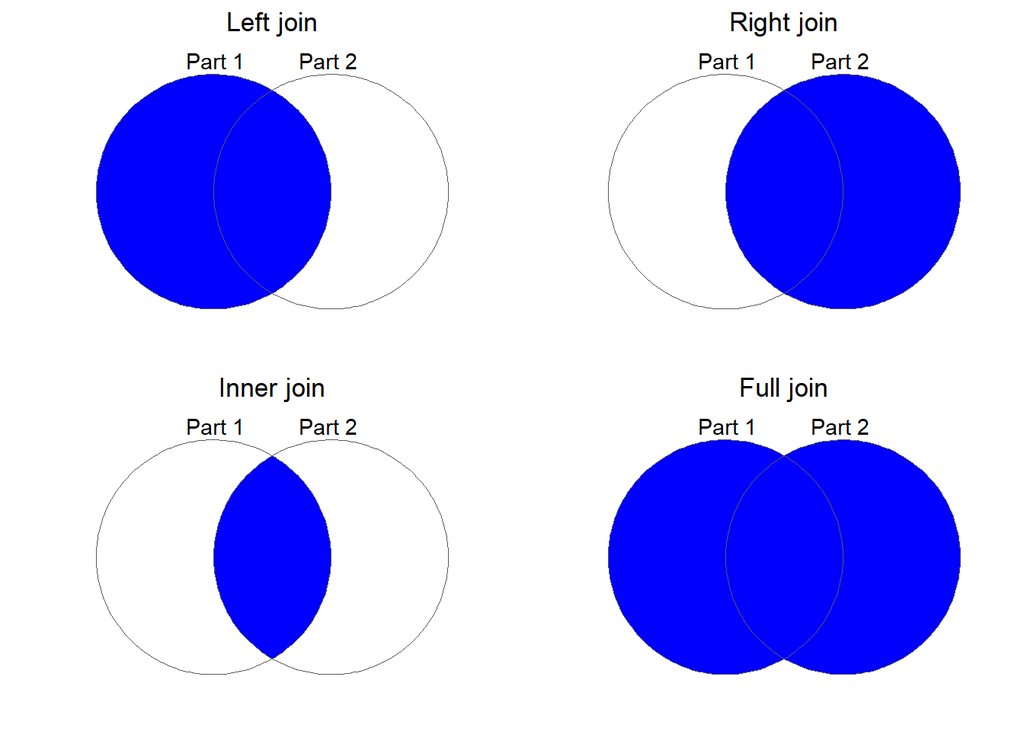

Different types of joins between two data sets

Define two subsets. Create a subset called Part1 where trt is equal to 1 and the time span is from 11 to 12. Let the subset contain this two variables celltype and karno. Create a subset called Part2 where trt is equal to 2 and the time span is from 49 to 51. Let the subset contain this two variables celltype and time.

```r
Part1 <- vet %>%
  filter(trt == 1 & between(time, 11, 12)) %>%
  select(celltype, karno)
Part2 <- vet %>%
  filter(trt == 2 & between(time, 49, 51)) %>%
  select(celltype, time)

#example
left_join(___, ___, by="celltype")
```

##### 1. (Left join) Merge Part1 together with Part2 with a left join

**Show the solution for 1**

```r
left_join(Part1, Part2, by = "celltype")
```

```
##   celltype karno time
## 1        1    70   NA
## 2        3    50   51
## 3        4    40   49
```

##### 2. (Right join) Merge Part1 together with Part2 with a right join

**Show the solution for 2**

```r
right_join(Part1, Part2, by = "celltype")
```

```
##   celltype karno time
## 1        3    50   51
## 2        4    40   49
## 3        2    NA   51
```

and this

```r
left_join(Part2, Part1, by="celltype")
```

```
##   celltype time karno
## 1        2   51    NA
## 2        3   51    50
## 3        4   49    40
```

##### 3. (Inner join) Merge Part1 together with Part2 with an inner join with and without specifying the statement “by”

**Show the solution for 3**

```r
inner_join(Part1, Part2) # note here inner_join joins on columns common to both datasets - usually better to specify explicitly
```

```
##   celltype karno time
## 1        3    50   51
## 2        4    40   49
```

```r
inner_join(Part1, Part2, by = "celltype")
```

```
##   celltype karno time
## 1        3    50   51
## 2        4    40   49
```

##### 4. (Full join) Merge Part1 together with Part2 with a full join

**Show the solution for 4**

```r
full_join(Part1, Part2, by = "celltype")
```

```
##   celltype karno time
## 1        1    70   NA
## 2        3    50   51
## 3        4    40   49
## 4        2    NA   51
```

### Exercise 3 - Making plots with ggplot

[Click here for a cheatsheet for ggplot](https://statsandr.com/blog/files/ggplot2-cheatsheet.pdf)

##### 1. Load the .RData file datasets::airquality into R. Define the data as air. Look at the first 6 observations and a summary of the variables in air.

**Show the solution for 1**

```r
air <- datasets::airquality
air %>%
  head()
```

```
##   Ozone Solar.R Wind Temp Month Day
## 1    41     190  7.4   67     5   1
## 2    36     118  8.0   72     5   2
## 3    12     149 12.6   74     5   3
## 4    18     313 11.5   62     5   4
## 5    NA      NA 14.3   56     5   5
## 6    28      NA 14.9   66     5   6
```

```r
air %>%
  summary()
```

```
##      Ozone           Solar.R           Wind             Temp
##  Min.   :  1.00   Min.   :  7.0   Min.   : 1.700   Min.   :56.00
##  1st Qu.: 18.00   1st Qu.:115.8   1st Qu.: 7.400   1st Qu.:72.00
##  Median : 31.50   Median :205.0   Median : 9.700   Median :79.00
##  Mean   : 42.13   Mean   :185.9   Mean   : 9.958   Mean   :77.88
##  3rd Qu.: 63.25   3rd Qu.:258.8   3rd Qu.:11.500   3rd Qu.:85.00
##  Max.   :168.00   Max.   :334.0   Max.   :20.700   Max.   :97.00
##  NA's   :37       NA's   :7
##      Month            Day
##  Min.   :5.000   Min.   : 1.0
##  1st Qu.:6.000   1st Qu.: 8.0
##  Median :7.000   Median :16.0
##  Mean   :6.993   Mean   :15.8
##  3rd Qu.:8.000   3rd Qu.:23.0
##  Max.   :9.000   Max.   :31.0
##
```

##### 2. Make a scatter plot with Ozone (y-axis) against Temp (x-axis) using ggplot.

**Show the solution for 2**

```
## Warning: Removed 37 rows containing missing values (`geom_point()`).
```

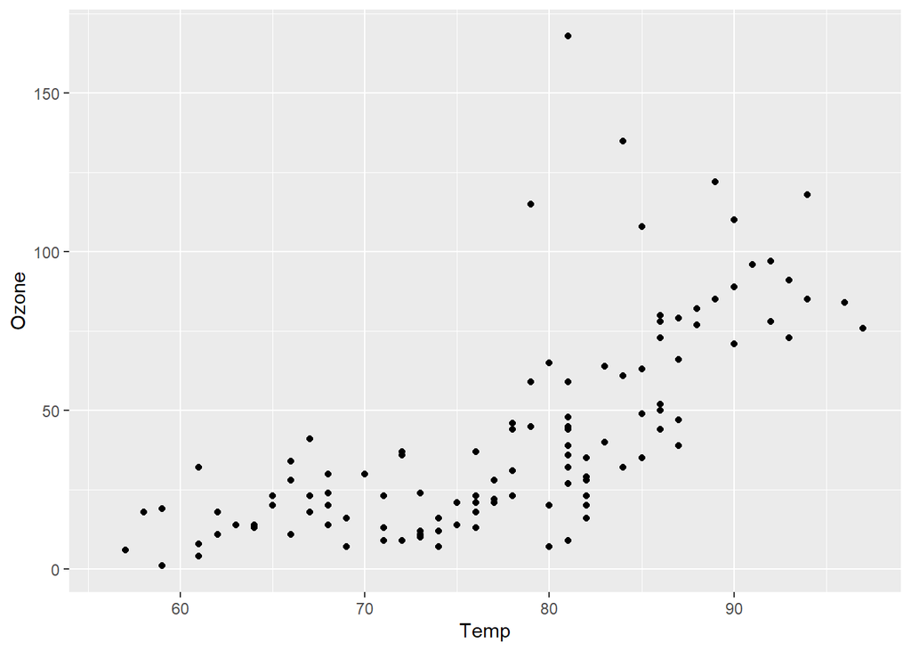

```r
air %>%
  ggplot(aes(x = Temp, y = Ozone)) +
  geom_point()
```

##### 3. You got a warning when you made the scatter plot. What does the warning mean? Ignore this warning in the rest of the exercise.

**Show the solution for 3**

```r
# The variable Ozone has 37 observations with missing values.
# The warning tells you that ggplot could not plot these 37
# points in the scatter plot. Sometimes warnings can be ignored
# other times not.
```

##### 4. Colour the dots in the scatter plot according to Month.

**Show the solution for 4**

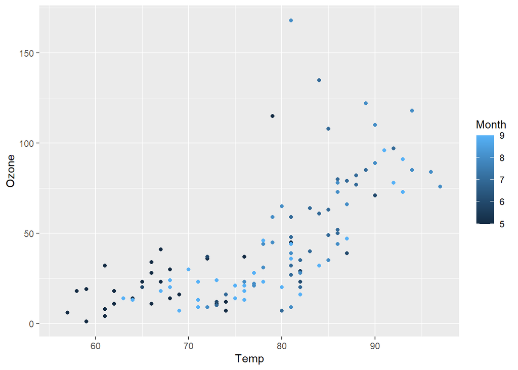

```r
air %>%
  ggplot(aes(x = Temp, y = Ozone, colour = Month)) +
  geom_point()
```

##### 5. You can define Month as a factor by writing factor(Month) instead of Month in the scatter plot. What happens to the colours in the scatter plot if you define Month as a factor?

**Show the solution for 5**

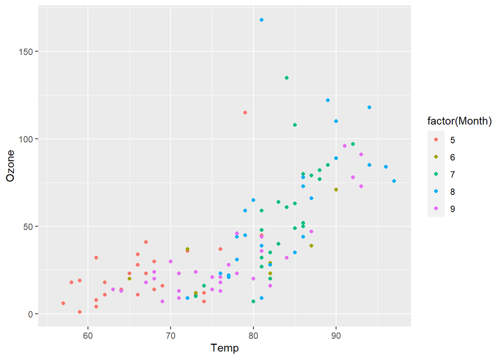

```r
air %>%
  ggplot(aes(x = Temp, y = Ozone, colour = factor(Month))) +
  geom_point()
```

##### 6. Further add a symbol for each Month in the scatter plot by adding shape = factor(Month).

**Show the solution for 6**

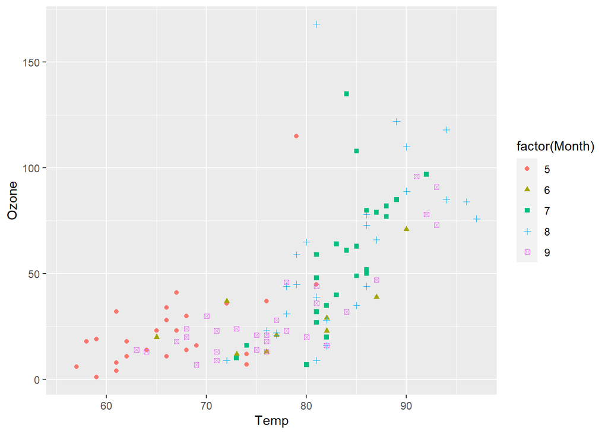

```r
air %>%
  ggplot(aes(x = Temp, y = Ozone, colour = factor(Month), shape = factor(Month))) +
  geom_point()
```

##### 7. When you changed Month to a factor variable the label for Month also changed in the scatter plot. Use labs() to change the label to Month instead of factor(Month). Be aware that that Month is used for both colour and shape.

**Show the solution for 7**

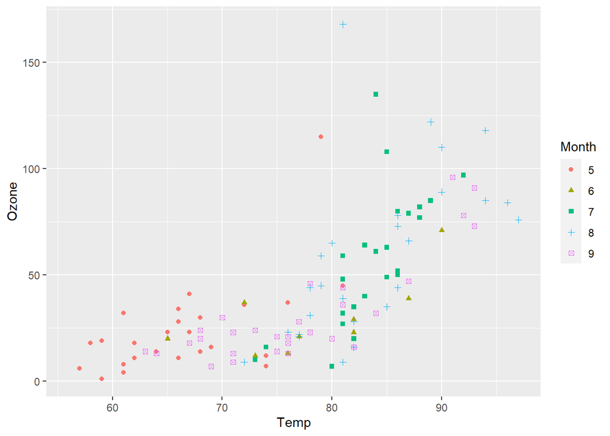

```r
air %>%
  ggplot(aes(x = Temp, y = Ozone, colour = factor(Month), shape = factor(Month))) +
  geom_point() +
  labs(colour = "Month", shape = "Month")
```

##### 8. Further add a title and nice labels to the x- and y-axis.

**Show the solution for 8**

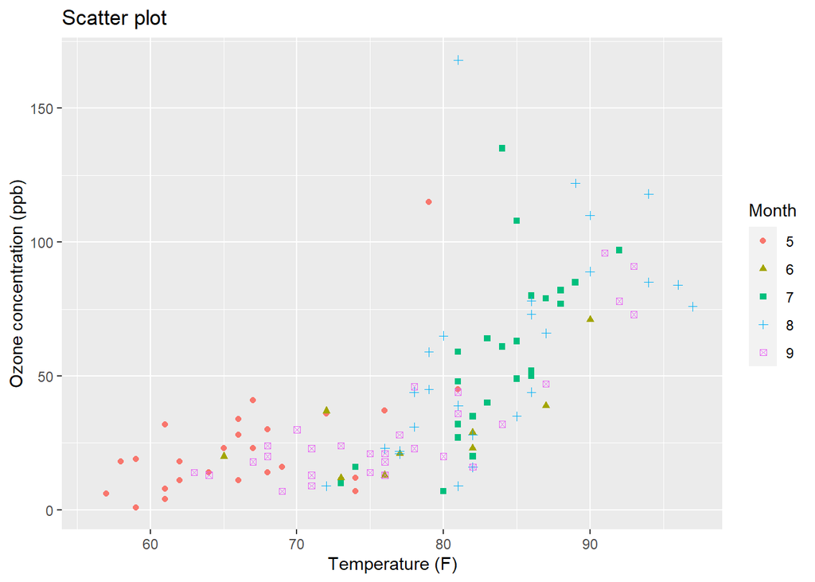

```r
air %>%
  ggplot(aes(x = Temp, y = Ozone, colour = factor(Month), shape = factor(Month))) +
  geom_point() +
  # When a line of code gets too long break it into smaller pieces
  labs(
    colour = "Month",
    shape = "Month",
    title = "Scatter plot",
    x = "Temperature (F)",
    y = "Ozone concentration (ppb)"
  )
```

##### 9. Save the scatter plot as a png file using ggsave. Use the width, height and dpi option to try out different sizes and resolutions for the png file.

**Show the solution for 9**

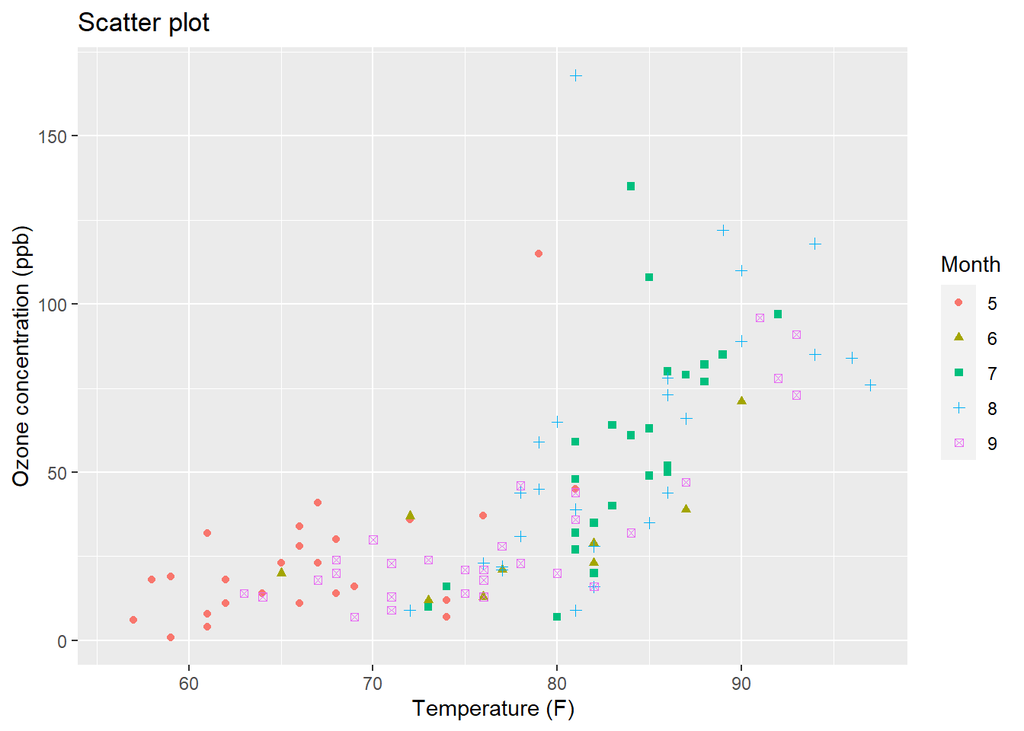

```r
air %>%
  ggplot(aes(x = Temp, y = Ozone)) +
  geom_point(aes(colour = factor(Month), shape = factor(Month))) +
  labs(
    colour = "Month",
    shape = "Month",
    title = "Scatter plot",
    x = "Temperature (F)",
    y = "Ozone concentration (ppb)"
  )
```

```r
ggsave(file = "./ScatterPlot.png", width = 10, height = 8, unit = "in", dpi = 300)
```

### Bonus exercises

These bonus exercises use the vet and air dataset from the previous exercises.

**Show the solution for 1**

```r
vet100samllcell <- vet %>%
  filter(celltype == 2 & time > 100)
vet100samllcell %>%
  head(n = 10)
```

```
##    trt celltype time status karno diagtime age prior
## 17   1        2  384      1    60        9  42     0
## 21   1        2  123      0    40        3  55     0
## 23   1        2  153      1    60       14  63    10
## 25   1        2  117      1    80        3  46     0
## 27   1        2  151      1    50       12  69     0
## 32   1        2  139      1    80        2  64     0
## 36   1        2  287      1    60       25  66    10
## 39   1        2  122      1    80       28  53     0
## 44   1        2  392      1    40        4  68     0
## 91   2        2  103      0    70       22  36    10
```

##### 2. The subset (vet100samllcell) from the previous exercise contain 8 variables. Select the following variables from the subset: trt, celltype, time, status, karno and age.

**Show the solution for 2**

```r
vet100samllcell %>%
  select(trt, celltype, time, status, karno, age) %>%
  head(n = 10)
```

```
##    trt celltype time status karno age
## 17   1        2  384      1    60  42
## 21   1        2  123      0    40  55
## 23   1        2  153      1    60  63
## 25   1        2  117      1    80  46
## 27   1        2  151      1    50  69
## 32   1        2  139      1    80  64
## 36   1        2  287      1    60  66
## 39   1        2  122      1    80  53
## 44   1        2  392      1    40  68
## 91   2        2  103      0    70  36
```

##### 3. Use vet to calculate the average of time and age, and add the averages as two new columns in the dataset.

**Show the solution for 3**

```r
vet %>%
  mutate(
    mean_time = mean(time, na.rm = TRUE),
    mean_age = mean(age, na.rm = TRUE)
    ) %>%
  head(n = 10)
```

```
##    trt celltype time status karno diagtime age prior mean_time mean_age
## 1    1        1   72      1    60        7  69     0  121.6277 58.41221
## 2    1        1  411      1    70        5  64    10  121.6277 58.41221
## 3    1        1  228      1    60        3  NA     0  121.6277 58.41221
## 4    1        1  126      1    60        9  63    10  121.6277 58.41221
## 5    1        1  118      1    70       11  NA    10  121.6277 58.41221
## 6    1        1   10      1    20        5  49     0  121.6277 58.41221
## 7    1        1   82      1    40       10  69    10  121.6277 58.41221
## 8    1        1  110      1    80       29  NA     0  121.6277 58.41221
## 9    1        1  314      1    50       18  43     0  121.6277 58.41221
## 10   1        1  100      0    70        6  70     0  121.6277 58.41221
```

##### 4. Calculate the average of time and age grouped by the variable celltype, and add the averages as two new columns in the dataset.

**Show the solution for 4**

```r
vet %>%
  group_by(celltype) %>%
  mutate(
    celltype_mean_time = mean(time, na.rm = TRUE),
    celltype_mean_age = mean(age, na.rm = TRUE)
    ) %>%
  head(n = 10)
```

```
## # A tibble: 10 × 10
## # Groups:   celltype [1]
##      trt celltype  time status karno diagtime   age prior celltype_mean_time
##    <dbl> <fct>    <dbl>  <dbl> <dbl>    <dbl> <dbl> <dbl>              <dbl>
##  1     1 1           72      1    60        7    69     0               200.
##  2     1 1          411      1    70        5    64    10               200.
##  3     1 1          228      1    60        3    NA     0               200.
##  4     1 1          126      1    60        9    63    10               200.
##  5     1 1          118      1    70       11    NA    10               200.
##  6     1 1           10      1    20        5    49     0               200.
##  7     1 1           82      1    40       10    69    10               200.
##  8     1 1          110      1    80       29    NA     0               200.
##  9     1 1          314      1    50       18    43     0               200.
## 10     1 1          100      0    70        6    70     0               200.
## # ℹ 1 more variable: celltype_mean_age <dbl>
```

##### 5. Create a subset called a_cell. This subset must only contain veterans with the celltype being equal to 3 (adeno) and all the veterans have to be strictly younger than 60.

**Show the solution for 5.1**

```r
a_cell <- vet %>%
  filter(celltype == 3 & age < 60)
a_cell %>%
  head()
```

```
##     trt celltype time status karno diagtime age prior
## 49    1        3  117      1    80        2  38     0
## 50    1        3  132      1    80        5  50     0
## 53    1        3    3      1    30        3  43     0
## 54    1        3   95      1    80        4  34     0
## 110   2        3   83      0    99        3  57     0
## 113   2        3   90      1    60       22  50    10
```

Create an additional subset called l_cell. This subset must only contain veterans with the celltype being equal to 4 (large) and all the veterans have to be strictly older than 40.

**Show the solution for 5.2**

```r
l_cell <- vet %>%
  filter(celltype == 4 & age > 40)
l_cell %>%
  head()
```

```
##    trt celltype time status karno diagtime age prior
## 55   1        4  177      1    50       16  66    10
## 56   1        4  162      1    80        5  62     0
## 57   1        4  216      1    50       15  52     0
## 58   1        4  553      1    70        2  47     0
## 59   1        4  278      1    60       12  63     0
## 60   1        4   12      1    40       12  68    10
```

##### 6. Create a new dataset called al_cell by combining by rows the two subsets a_cell and l_cell. Use head() and tail() to look at the 6 first and 6 last observations in the combined dataset.

**Show the solution for 6**

```r
al_cell <- bind_rows(a_cell, l_cell)
al_cell %>%
  head()
```

```
##     trt celltype time status karno diagtime age prior
## 49    1        3  117      1    80        2  38     0
## 50    1        3  132      1    80        5  50     0
## 53    1        3    3      1    30        3  43     0
## 54    1        3   95      1    80        4  34     0
## 110   2        3   83      0    99        3  57     0
## 113   2        3   90      1    60       22  50    10
```

```r
al_cell %>%
  tail()
```

```
##     trt celltype time status karno diagtime age prior
## 131   2        4   43      1    60       11  49    10
## 132   2        4  340      1    80       10  64    10
## 133   2        4  133      1    75        1  65     0
## 134   2        4  111      1    60        5  64     0
## 135   2        4  231      1    70       18  67    10
## 136   2        4  378      1    80        4  65     0
```

##### 7. Create two new datasets from a_cell. Create the first dataset by only selecting the variable karno and the second by removing the variable karno. Call the dataets a_cell_only_karno and a_cell_without_karno. Then merge the columns of the two datasets together and call the new merged dataset a_cell_karno. Use head() to check what happens to the data in each step and check that the dataset a_cell is equal to a_cell_karno.

**Show the solution for 7**

```r
#Create a dataset only with karno
a_cell_only_karno <- a_cell %>%
  select(karno)
a_cell_only_karno %>%
  head()
```

```
##     karno
## 49     80
## 50     80
## 53     30
## 54     80
## 110    99
## 113    60
```

```r
#Create a dataset without karno
a_cell_without_karno <- a_cell %>%
  select(-karno)
a_cell_without_karno %>%
  head()
```

```
##     trt celltype time status diagtime age prior
## 49    1        3  117      1        2  38     0
## 50    1        3  132      1        5  50     0
## 53    1        3    3      1        3  43     0
## 54    1        3   95      1        4  34     0
## 110   2        3   83      0        3  57     0
## 113   2        3   90      1       22  50    10
```

```r
#Bind the two datasets together again (only works since the order of the obs is the same)
a_cell_karno <- bind_cols(a_cell_without_karno, a_cell_only_karno)
#Check that a_call and a_cell_karno are exactly the same (except for the order of the columns)
all(a_cell_karno[, colnames(a_cell)] == a_cell)
```

```
## [1] TRUE
```

##### 8. Calculate the average of the variable karno grouped by the variable celltype.

**Show the solution for 8**

```r
vet %>%
  group_by(celltype) %>%
  summarise(avg_karno = mean(karno, na.rm = TRUE))
```

```
## # A tibble: 4 × 2
##   celltype avg_karno
##   <fct>        <dbl>
## 1 1             60.9
## 2 2             53.5
## 3 3             58.1
## 4 4             65
```

##### 9. Calculate the average of the two variables karno and diagtime grouped by the variable celltype

**Show the solution for 9**

```r
vet %>%
  group_by(celltype) %>%
  summarise(
    avg_karno = mean(karno, na.rm = TRUE),
    avg_diagtime = mean(diagtime, na.rm = TRUE)
    )
```

```
## # A tibble: 4 × 3
##   celltype avg_karno avg_diagtime
##   <fct>        <dbl>        <dbl>
## 1 1             60.9        11.0
## 2 2             53.5         9.25
## 3 3             58.1         5.63
## 4 4             65           8.15
```

##### 10. Calculate the average of the two variables karno and diagtime grouped by the variable celltype. Add also the counting variable that counts the number of observations in the data for each celltype.

**Show the solution for 10**

```r
vet %>%
  group_by(celltype) %>%
  summarise(
    avg_karno = mean(karno, na.rm = TRUE),
    avg_diagtime = mean(diagtime, na.rm = TRUE),
    count = n()
    )
```

```
## # A tibble: 4 × 4
##   celltype avg_karno avg_diagtime count
##   <fct>        <dbl>        <dbl> <int>
## 1 1             60.9        11.0     35
## 2 2             53.5         9.25    48
## 3 3             58.1         5.63    27
## 4 4             65           8.15    27
```

**Show the solution for 11**

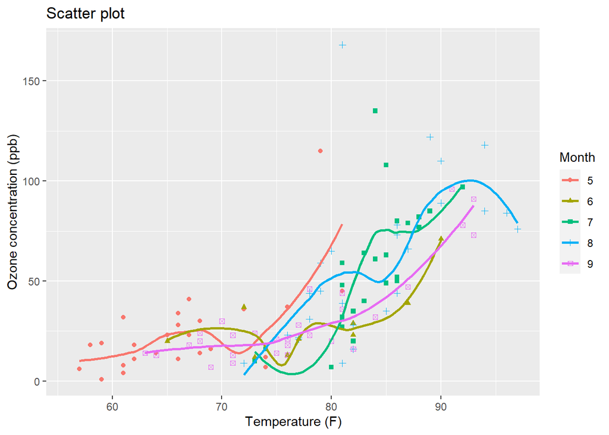

```r
#A smoothed line for each month
air %>%
  ggplot(aes(x = Temp, y = Ozone, colour = factor(Month), shape = factor(Month))) +
  geom_point() +
  geom_smooth(se = F) +
  labs(
    colour = "Month",
    shape = "Month",
    title = "Scatter plot",
    x = "Temperature (F)",
    y = "Ozone concentration (ppb)"
    )
```

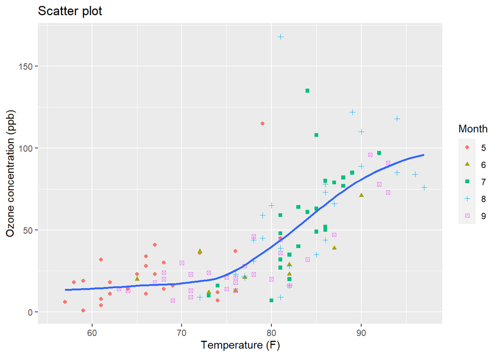

```r
#One smooth line
air %>%
  ggplot(aes(x = Temp, y = Ozone)) +
  geom_point(aes(colour = factor(Month), shape = factor(Month))) +
  geom_smooth(se = F) +
  labs(
    colour = "Month",
    shape = "Month",
    title = "Scatter plot",
    x = "Temperature (F)",
    y = "Ozone concentration (ppb)"
    )
```

##### 12. Change the theme of the scatter plot by adding theme_bw().

**Show the solution for 12**

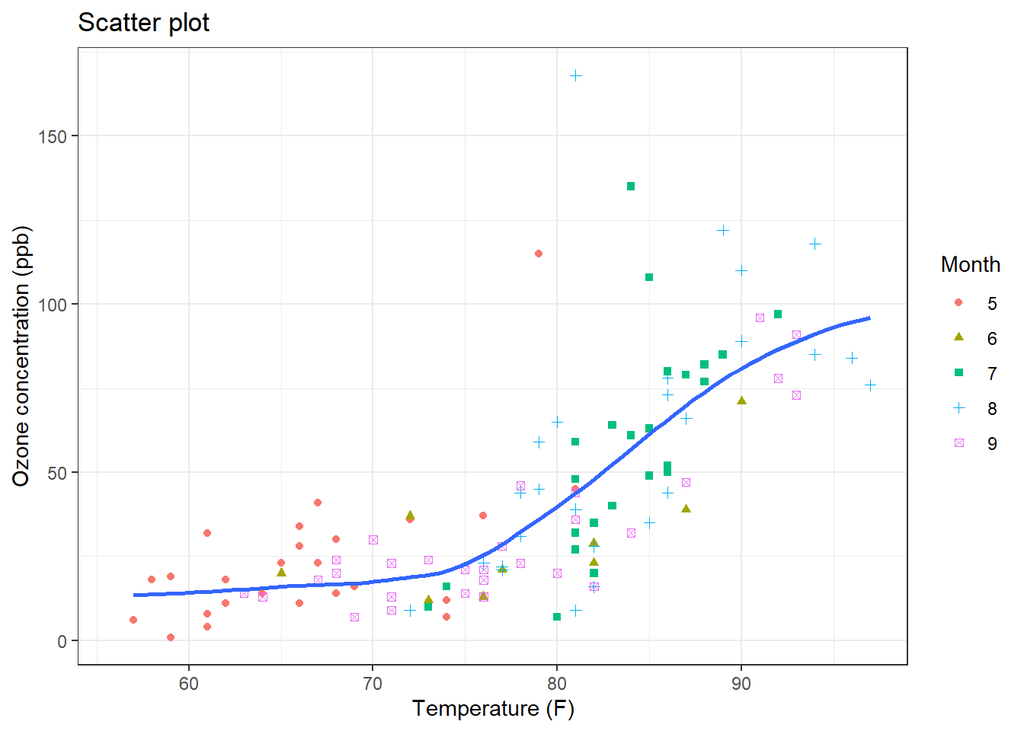

```r
air %>%
  ggplot(aes(x = Temp, y = Ozone)) +
  geom_point( aes(colour = factor(Month), shape = factor(Month))) +
  geom_smooth(se = F) +
  labs(
    colour = "Month",
    shape = "Month",
    title = "Scatter plot",
    x = "Temperature (F)",
    y = "Ozone concentration (ppb)"
  ) +
  theme_bw()
```